# Testing for Lab 1

Cale Bible

09-02-2025

# Tasks

These are the tasks for the first lab.

## Task 1

```r
setwd("C:/Users/golfe/Desktop/Applied Statistical Methods/LAB1")
getwd()
```

```
## [1] "C:/Users/golfe/Desktop/Applied Statistical Methods/LAB1"
```

```r
list.files()
```

```
## [1] "DATAxls"   "lab1.html" "lab1.R"    "lab1.Rmd"
```

## Task 2

Reading in the data into ddt.

```r
ddt <- read.csv("Dataxls/Dataxls/DDT.csv")
head(ddt)
```

```
##   RIVER MILE  SPECIES LENGTH WEIGHT DDT
## 1   FCM    5 CCATFISH   42.5    732  10
## 2   FCM    5 CCATFISH   44.0    795  16
## 3   FCM    5 CCATFISH   41.5    547  23
## 4   FCM    5 CCATFISH   39.0    465  21
## 5   FCM    5 CCATFISH   50.5   1252  50
## 6   FCM    5 CCATFISH   52.0   1255 150
```

## Task 3

```r
class(ddt$SPECIES)
```

```
## [1] "character"
```

```r
class(ddt$RIVER)
```

```
## [1] "character"
```

- Likewise, we can conclude the quantitative variables of the data frame are: MILE, LENGTH, and WEIGHT

```r
class(ddt$MILE)
```

```
## [1] "integer"
```

```r
class(ddt$LENGTH)
```

```
## [1] "numeric"
```

```r
class(ddt$WEIGHT)
```

```
## [1] "integer"
```

Next, finding observations with SPECIES, LMBASS and WEIGHT bigger than 800gms. We set species equal to “LMBASS” and WEIGHT>800.

```r
with(ddt, ddt[WEIGHT>800 & SPECIES=="LMBASS",])
```

```
##     RIVER MILE SPECIES LENGTH WEIGHT DDT
## 141   TRM  345  LMBASS     30    856 2.2
## 144   TRM  345  LMBASS     36   1433 1.9
```

Next, finding observations where the RIVER is SCM and DDT bigger than 4.0. We set RIVER equal to “SCM” and DDT>4.0.

```r
with(ddt, ddt[RIVER=="SCM" & DDT>4.0,])
```

```
##    RIVER MILE  SPECIES LENGTH WEIGHT DDT
## 16   SCM    1 CCATFISH     45    984 9.1
## 17   SCM    1 CCATFISH     43    965 7.8
## 18   SCM    1 CCATFISH     45   1084 4.1
```

## Task 4

The mean of length of fish:

```r
mean(ddt$LENGTH)
```

```
## [1] 42.8125
```

Finding the standard deviation of weight.

```r
sd(ddt$WEIGHT)
```

```
## [1] 376.5461
```

Verifying length vs weight

[figure not shown]

```r
plot(ddt$LENGTH, ddt$WEIGHT, ylab="LENGTH", xlab="WEIGHT")
```

```r
1
```

```
## [1] 1
```

Last value of v/20:

```r
v=1:20
v/20
```

```
##  [1] 0.05 0.10 0.15 0.20 0.25 0.30 0.35 0.40 0.45 0.50 0.55 0.60 0.65 0.70 0.75
## [16] 0.80 0.85 0.90 0.95 1.00
```

## Task 5

Table of rivers

```r
# Turning RIVERS into subtable.
rivers=with(ddt, table(RIVER))
rivers
```

```
## RIVER
## FCM LCM SCM TRM
##   6   6   6 126
```

Creating color coded bar plot.

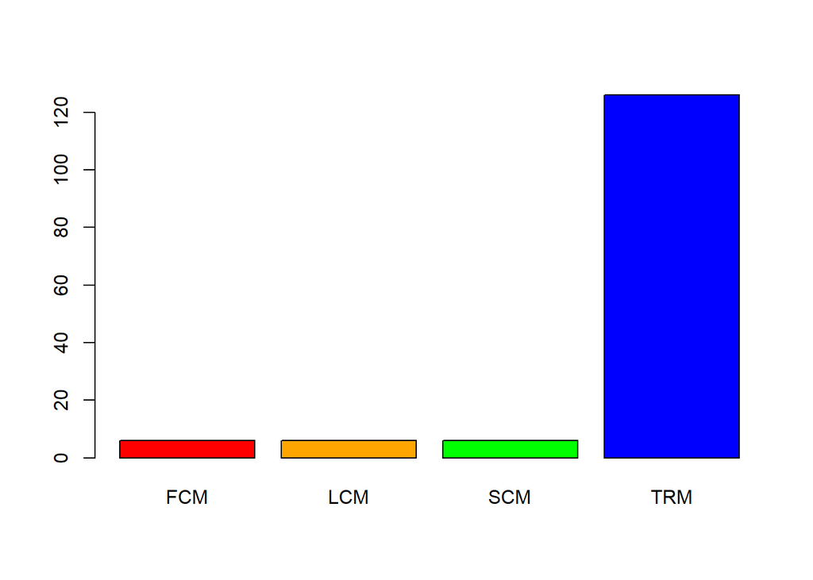

```r
barplot(rivers, col=c("red", "orange", "green", "blue"))
```

```r
# Rivers crossed with fish.
rcf <- with(ddt, c(RIVER, SPECIES))
```

Making a barplot with rivers crossed with species of fish.

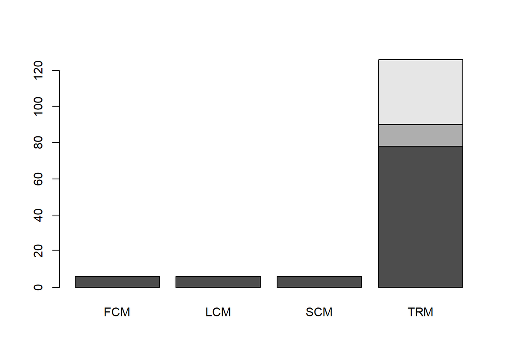

```r
# Rivers crossed with fish.
fcr <- with(ddt, table(SPECIES, RIVER))
barplot(fcr)
```

## Task 6

Making pie chart of fish species.

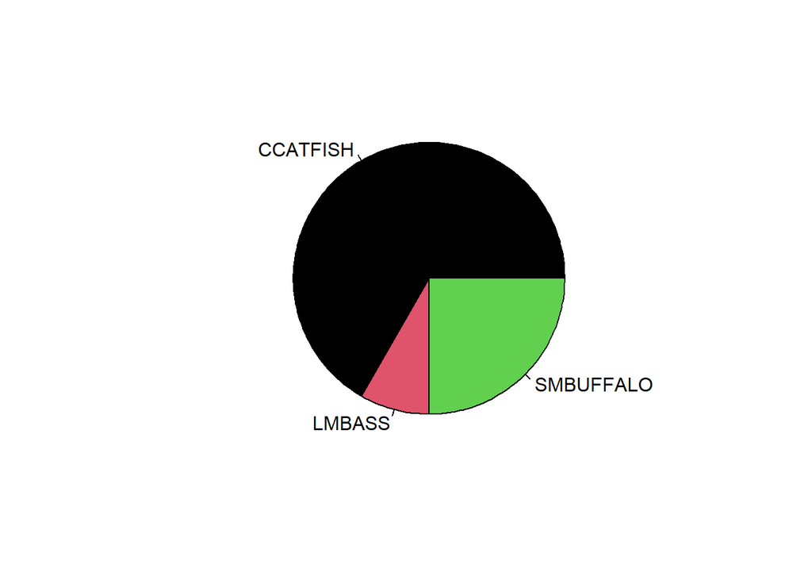

```r
pdata <- with(ddt, table(SPECIES))
pie(pdata, col=1:3)
```

Making pie chart of rivers

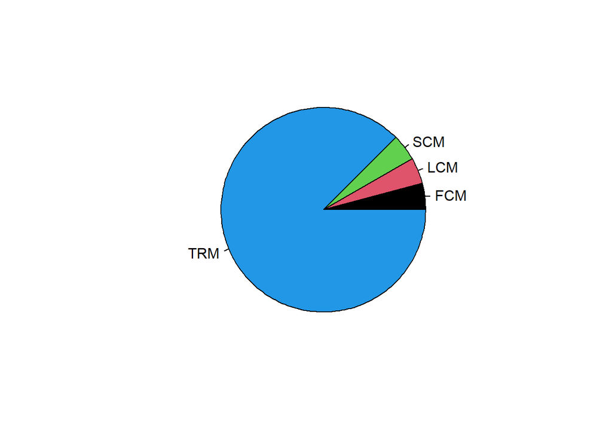

```r
ridata <- with(ddt, table(RIVER))
pie(ridata, col=1:4)
```

## Task 7

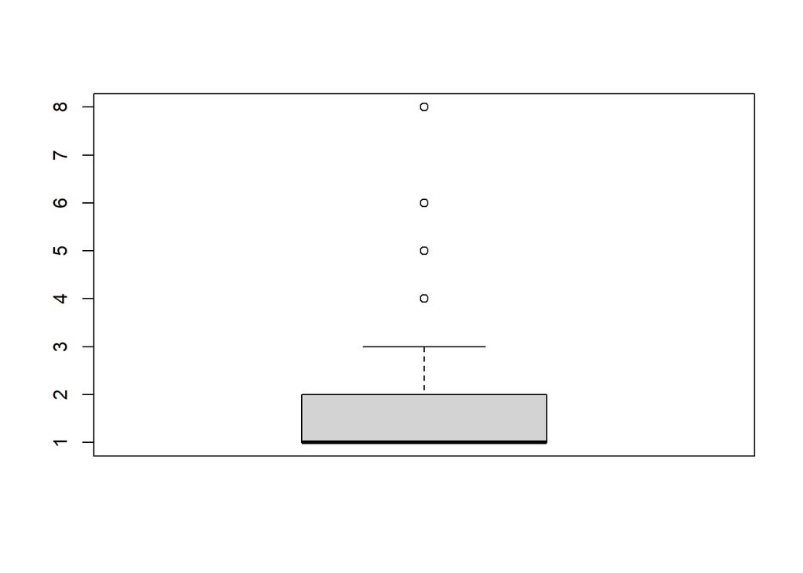

```r
boxplot(with(ddt, table(DDT)))
```

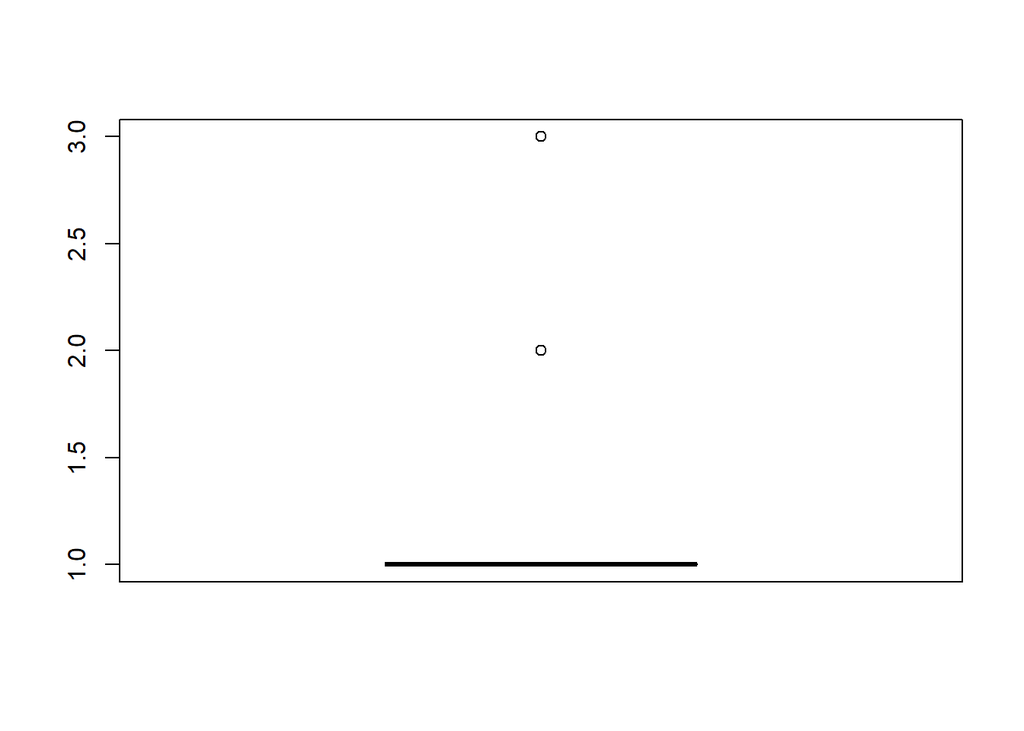

```r
boxplot(with(ddt, table(WEIGHT)))
```

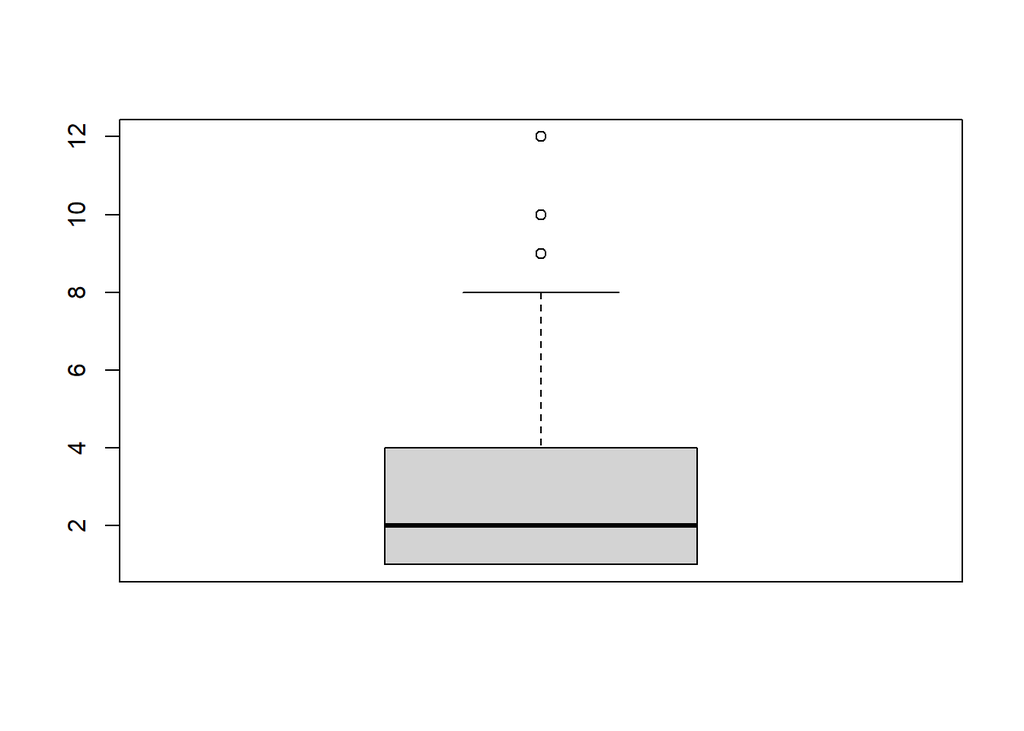

```r
boxplot(with(ddt, table(LENGTH)))
```

## Task 8

Making a coplot of LENGTH Vs WEIGHT given RIVER

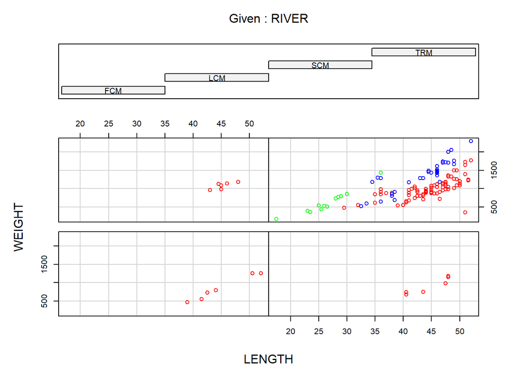

```r
fishcol=with(ddt,ifelse(SPECIES=="CCATFISH","Red",
                        ifelse(SPECIES=="SMBUFFALO","Blue","Green")))
rivcol=with(ddt, ifelse(RIVER=="FCM","Red",
                        ifelse(RIVER=="LCM","Blue",
                               ifelse(RIVER=="SCM","Green","Black"))))
coplot(WEIGHT~LENGTH|RIVER,data=ddt,col=fishcol)
```

Making a coplot of DDT Vs WEIGHT given SPECIES

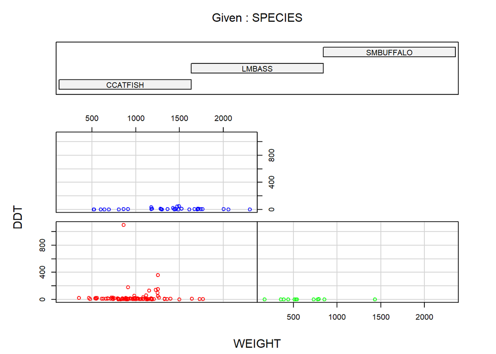

```r
coplot(DDT~WEIGHT|SPECIES,data=ddt,col=fishcol)
```

## Task 9

Create first ggplot2 graph.

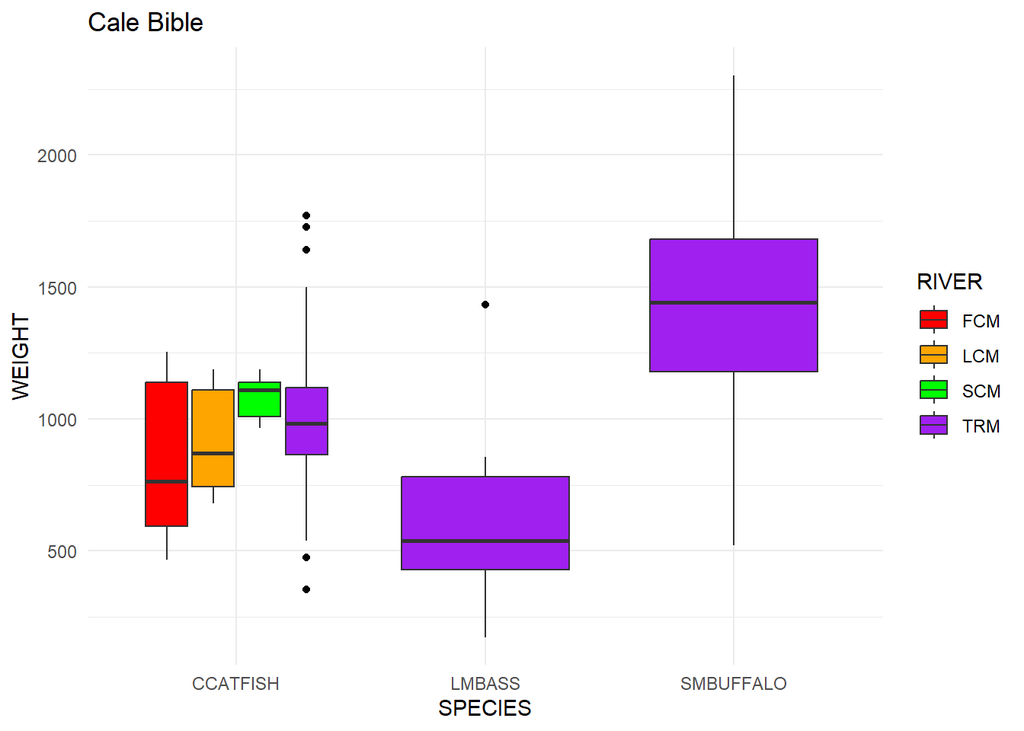

```r
library(ggplot2)
ggplot(ddt, aes(x = SPECIES, y = WEIGHT, fill = RIVER)) +
  geom_boxplot(outlier.shape = 16, outlier.color = "black") +
  scale_fill_manual(values = c("FCM" = "red", "LCM" = "orange", "SCM" = "green", "TRM" = "purple")) +
  labs(title = "Cale Bible",
       x = "SPECIES",
       y = "WEIGHT",
       fill = "RIVER") +
  theme_minimal()
```

Create ggplot2 graph.

[figure not shown]

```r
ggplot(ddt, aes(x = RIVER, y = LENGTH, fill = SPECIES)) +
  geom_violin() +
  scale_fill_manual(values = c("CCATFISH" = "red", "LMBASS" = "green", "SMBUFFALO" = "blue")) +
  labs(title = "Cale Bible",
       x = "SPECIES",
       y = "WEIGHT",
       fill = "RIVER") +
  theme_minimal()
```